# Homework 2: R programming - Question 1

Viviana Alejandra Rodriguez Romero

September 27, 2017

## Question 1

1. Load the built-in dataset **state** into R’s memory.

```r
data(state)
```

2. List the objects in your R session. Get help for the **state** object.

The objects in the R session are:

```r
ls()
```

```
## [1] "state.abb"      "state.area"     "state.center"   "state.division"
## [5] "state.name"     "state.region"   "state.x77"
```

```r
?state
```

```
## starting httpd help server ... done
```

3. What type of object is **state.x77**?

```r
class(state.x77)
```

```
## [1] "matrix"
```

**state.x77** is a matrix object.

4. Create a new object called **new.state** that is a **data.frame** based on the data stored in **state.x77**.

```r
new.state<-as.data.frame(state.x77)
```

5. Attach the **new.state** object into the search path.

```r
attach(new.state)
```

6. Compute the mean of the **Illiteracy** vector from the **new.state** object, and its residuals from the mean value.

```r
m<-mean(Illiteracy)
new.state$resid<-Illiteracy-m
#The residuals are:
new.state$resid
```

```
##  [1]  0.93  0.33  0.63  0.73 -0.07 -0.47 -0.07 -0.27  0.13  0.83  0.73
## [12] -0.57 -0.27 -0.47 -0.67 -0.57  0.43  1.63 -0.47 -0.27 -0.07 -0.27
## [23] -0.57  1.23 -0.37 -0.57 -0.57 -0.67 -0.47 -0.07  1.03  0.23  0.63
## [34] -0.37 -0.37 -0.07 -0.57 -0.17  0.13  1.13 -0.67  0.53  1.03 -0.57
## [45] -0.57  0.23 -0.57  0.23 -0.47 -0.57
```

The mean of the **Illiteracy** is 1.17. The residuals from the mean of **Illiteracy** are storage on **new.state** as **resid** vector.

7. Print the elements of **Illiteracy** that are greater than the median illiteracy. Print the elements of **Murder** that are greater than its median.

The elements of **Illiteracy** that are greater than its median are:

```r
new.state[Illiteracy>median(Illiteracy),"Illiteracy",drop=FALSE]
```

```
##                Illiteracy
## Alabama               2.1
## Alaska                1.5
## Arizona               1.8
## Arkansas              1.9
## California            1.1
## Connecticut           1.1
## Florida               1.3
## Georgia               2.0
## Hawaii                1.9
## Kentucky              1.6
## Louisiana             2.8
## Massachusetts         1.1
## Mississippi           2.4
## New Jersey            1.1
## New Mexico            2.2
## New York              1.4
## North Carolina        1.8
## Oklahoma              1.1
## Pennsylvania          1.0
## Rhode Island          1.3
## South Carolina        2.3
## Tennessee             1.7
## Texas                 2.2
## Virginia              1.4
## West Virginia         1.4
```

The elements of **Murder** that are greater than its median are:

```r
new.state[Murder>median(Murder),"Murder",drop=FALSE]
```

```
##                Murder
## Alabama          15.1
## Alaska           11.3
## Arizona           7.8
## Arkansas         10.1
## California       10.3
## Florida          10.7
## Georgia          13.9
## Illinois         10.3
## Indiana           7.1
## Kentucky         10.6
## Louisiana        13.2
## Maryland          8.5
## Michigan         11.1
## Mississippi      12.5
## Missouri          9.3
## Nevada           11.5
## New Mexico        9.7
## New York         10.9
## North Carolina   11.1
## Ohio              7.4
## South Carolina   11.6
## Tennessee        11.0
## Texas            12.2
## Virginia          9.5
## Wyoming           6.9
```

8. Plot **Illiteracy** on the x-axis and Murder on the y-axis. From interacting with the graph, what 3 states have the highest murder rates?

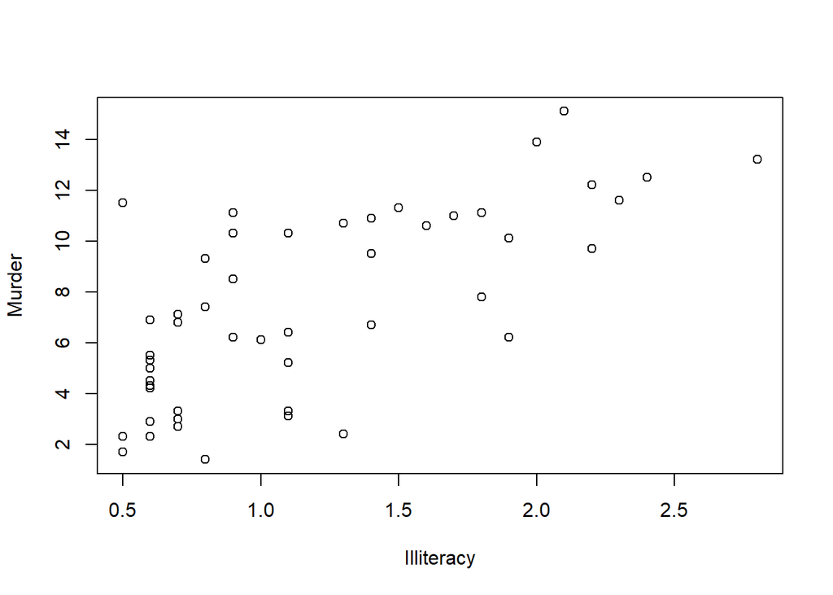

```r
plot(Illiteracy, Murder)
q1.h<-identify(Illiteracy, Murder , labels=row.names(new.state)) # identify points
```

The states with the highest murder rates are Alabama, Georgia, and Louisiana.

1. The plot function has an optional argument, type, that controls what type of plot is made (points, lines, etc). In particular, **type = ‘n’** plots nothing, but sets up and draws axes and axis labels. Use this to generate a scatterplot of **Illiteracy** and **Murder**, but with the state abbreviations labeling the points, instead of the default plotting character.

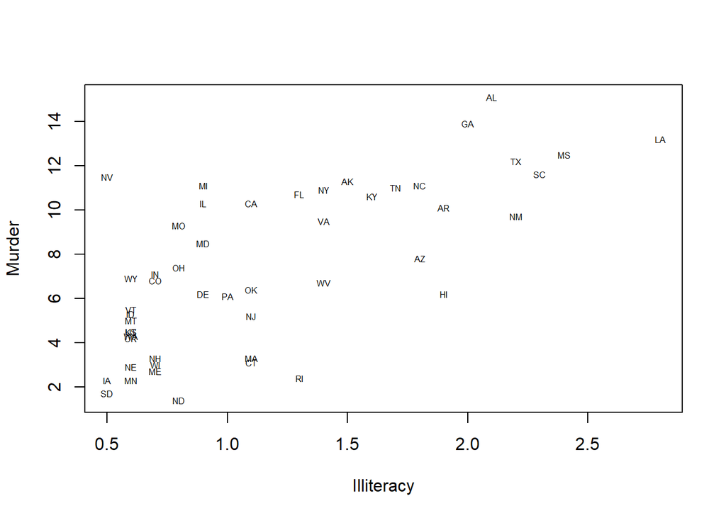

```r
plot(Illiteracy, Murder, type = 'n')
text(Illiteracy, Murder,labels=state.abb, cex= 0.5)
```

10. Write a function is.min that returns a logical vector identifying the minimum values. Write another function (call it **mins**) that calls **is.min** and returns the numerical indices of the minimum values. Apply mins to the **Illiteracy** vector.

```r
is.min<-function(v){
   v==min(v)
}

mins<-function(d, v){
  #d: dataset
  #v: variable
  rownames(d[is.min(v),])
}

mins(d=new.state, v=Illiteracy)
```

```
## [1] "Iowa"         "Nevada"       "South Dakota"
```

The minimum value of Illiteracy is 0.5 on the states: Iowa, Nevada, South Dakota.